# pjt_bank_marketing

Eunyoung Kwak, Cindy Miao, Haiying Lin, Susie Liang

2024-05-07

# 1. Data Preparation

- Banking Dataset - Marketing Targets
  - https://www.kaggle.com/datasets/prakharrathi25/banking-dataset-marketing-targets

```r
bank <- read_excel("bank.xlsx") # input data
str(bank)
```

```
## tibble [45,211 × 17] (S3: tbl_df/tbl/data.frame)
##  $ age      : num [1:45211] 27 54 43 27 28 29 38 36 32 44 ...
##  $ job      : chr [1:45211] "management" "blue-collar" "blue-collar" "technician" ...
##  $ marital  : chr [1:45211] "single" "married" "married" "single" ...
##  $ education: chr [1:45211] "secondary" "primary" "secondary" "secondary" ...
##  $ default  : chr [1:45211] "no" "no" "no" "no" ...
##  $ balance  : num [1:45211] 35 466 105 126 -127 ...
##  $ housing  : chr [1:45211] "no" "no" "no" "yes" ...
##  $ loan     : chr [1:45211] "no" "no" "yes" "yes" ...
##  $ contact  : chr [1:45211] "cellular" "cellular" "cellular" "cellular" ...
##  $ day      : num [1:45211] 4 4 4 4 4 4 4 4 4 4 ...
##  $ month    : chr [1:45211] "jul" "jul" "jul" "jul" ...
##  $ duration : num [1:45211] 255 297 668 436 1044 ...
##  $ campaign : num [1:45211] 1 1 2 4 3 2 3 6 3 2 ...
##  $ pdays    : num [1:45211] -1 -1 -1 -1 -1 -1 -1 -1 -1 -1 ...
##  $ previous : num [1:45211] 0 0 0 0 0 0 0 0 0 0 ...
##  $ poutcome : chr [1:45211] "unknown" "unknown" "unknown" "unknown" ...
##  $ y        : chr [1:45211] "no" "no" "no" "no" ...
```

## 7 Numarical Variables

```r
summary(bank[sapply(bank, is.numeric)])
```

```
##       age           balance            day           duration
##  Min.   :18.00   Min.   : -8019   Min.   : 1.00   Min.   :   0.0
##  1st Qu.:33.00   1st Qu.:    72   1st Qu.: 8.00   1st Qu.: 103.0
##  Median :39.00   Median :   448   Median :16.00   Median : 180.0
##  Mean   :40.94   Mean   :  1362   Mean   :15.81   Mean   : 258.2
##  3rd Qu.:48.00   3rd Qu.:  1428   3rd Qu.:21.00   3rd Qu.: 319.0
##  Max.   :95.00   Max.   :102127   Max.   :31.00   Max.   :4918.0
##     campaign          pdays          previous
##  Min.   : 1.000   Min.   : -1.0   Min.   :  0.0000
##  1st Qu.: 1.000   1st Qu.: -1.0   1st Qu.:  0.0000
##  Median : 2.000   Median : -1.0   Median :  0.0000
##  Mean   : 2.764   Mean   : 40.2   Mean   :  0.5803
##  3rd Qu.: 3.000   3rd Qu.: -1.0   3rd Qu.:  0.0000
##  Max.   :63.000   Max.   :871.0   Max.   :275.0000
```

## 10 Categorical Variables (including the target variable y)

```r
sapply(bank[sapply(bank, is.character)], unique)
```

```
## $job
##  [1] "management"    "blue-collar"   "technician"    "services"
##  [5] "admin."        "entrepreneur"  "housemaid"     "retired"
##  [9] "unknown"       "self-employed" "unemployed"    "student"
##
## $marital
## [1] "single"   "married"  "divorced"
##
## $education
## [1] "secondary" "primary"   "tertiary"  "unknown"
##
## $default
## [1] "no"  "yes"
##
## $housing
## [1] "no"  "yes"
##
## $loan
## [1] "no"  "yes"
##
## $contact
## [1] "cellular"  "telephone" "unknown"
##
## $month
##  [1] "jul" "aug" "oct" "nov" "dec" "jan" "feb" "mar" "apr" "may" "jun" "sep"
##
## $poutcome
## [1] "unknown" "failure" "other"   "success"
##
## $y
## [1] "no"  "yes"
```

```r
bank[sapply(bank, is.character)] <- lapply(bank[sapply(bank, is.character)], as.factor)
bank$month <- factor(bank$month, levels = c("jan", "feb", "mar", "apr", "may", "jun", "jul", "aug", "sep", "oct", "nov", "dec"))
bank$poutcome <- factor(bank$poutcome, levels = c("success", "failure", "unknown", "other"))
# str(bank)
summary(bank[sapply(bank, is.factor)])
```

```
##           job           marital          education     default     housing
##  blue-collar:9732   divorced: 5207   primary  : 6851   no :44396   no :20081
##  management :9458   married :27214   secondary:23202   yes:  815   yes:25130
##  technician :7597   single  :12790   tertiary :13301
##  admin.     :5171                    unknown  : 1857
##  services   :4154
##  retired    :2264
##  (Other)    :6835
##   loan            contact          month          poutcome       y
##  no :37967   cellular :29285   may    :13766   success: 1511   no :39922
##  yes: 7244   telephone: 2906   jul    : 6895   failure: 4901   yes: 5289
##              unknown  :13020   aug    : 6247   unknown:36959
##                                jun    : 5341   other  : 1840
##                                nov    : 3970
##                                apr    : 2932
##                                (Other): 6060
```

# 2. Exploratory Data Analysis

## Target Variable y Term deposit subscribed?

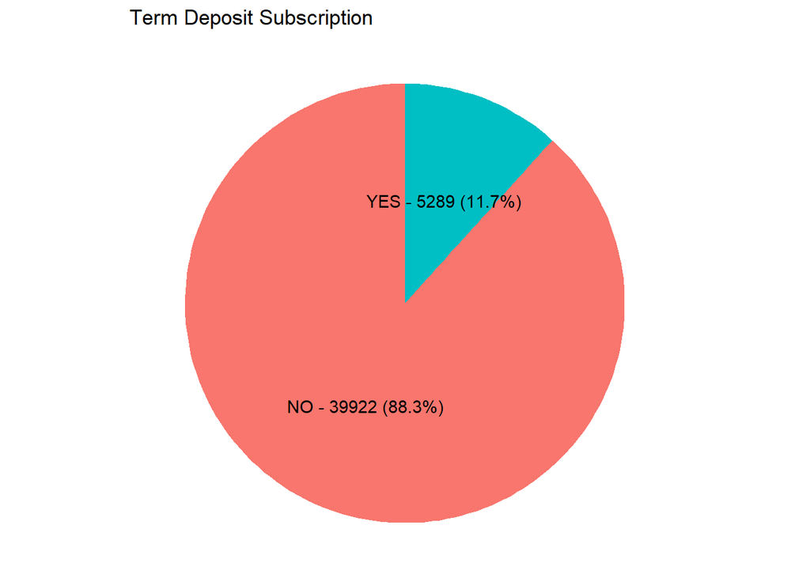

```r
# y_count <- table(bank$y)
# y_label <- paste0(toupper(names(y_count))," - ",y_count," (",round(y_count/sum(y_count)*100,1),"%)")
#
# pie(y_count, labels=y_label, col=c("#EE4E4E","#97BE5A"), main="Term deposit subscribed")

tibble(count = as.integer(table(bank$y)),
       label = paste0(toupper(names(table(bank$y)))," - ",table(bank$y)," (",round(table(bank$y)/sum(table(bank$y))*100,1),"%)")) %>%
  ggplot(aes(x = "", y = count, fill = label)) +
  geom_bar(stat = "identity", width = 1, show.legend = FALSE) +
  coord_polar(theta = "y") +
  theme_void() +
  labs(title = "Term Deposit Subscription") +
  geom_text(aes(label = label), position = position_stack(vjust = 0.5))
```

## Predictor variables: Numerical

- Most of them are right-skewed and have a lot of outliers.

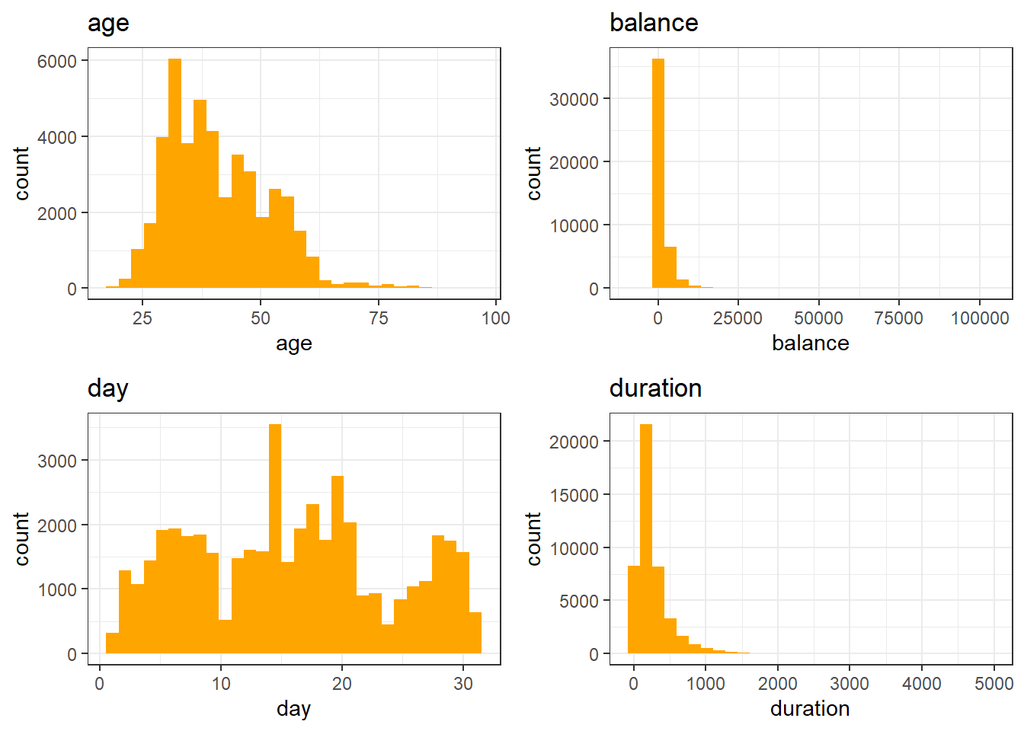

```r
colnm1 <- colnames(bank[sapply(bank, is.numeric)])

plot_list <- list()

for (i in  1:length(colnm1)) {
  plot_list[[i]] <- ggplot(bank) +
    geom_histogram(aes(x=!!sym(colnm1[i])), fill="orange", show.legend = FALSE, bins=30) +
    ggtitle(colnm1[i]) +
    theme_bw()
}

grid.arrange(plot_list[[1]], plot_list[[2]], plot_list[[3]], plot_list[[4]], ncol=2)
```

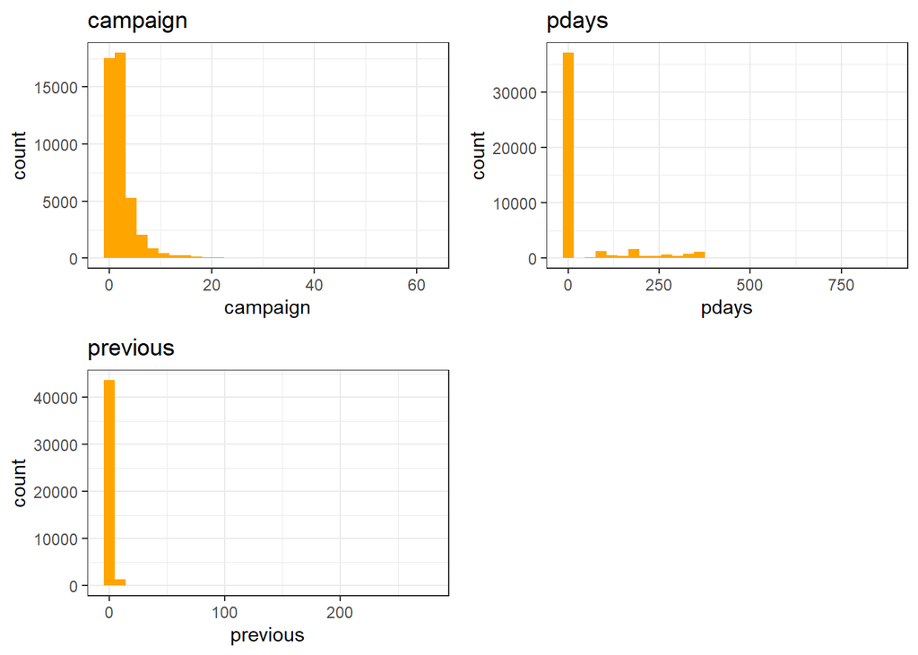

```r
grid.arrange(plot_list[[5]], plot_list[[6]], plot_list[[7]], ncol=2)
```

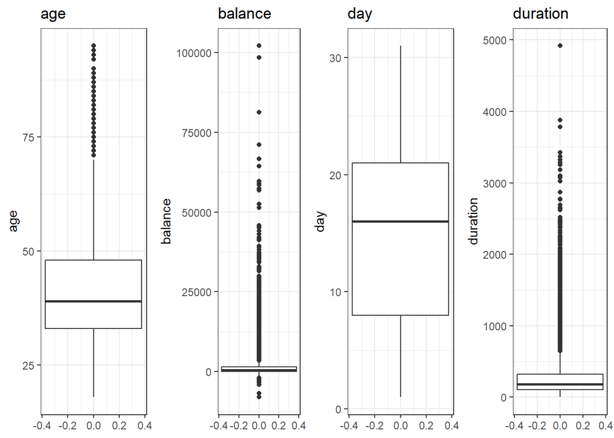

```r
colnm1 <- colnames(bank[sapply(bank, is.numeric)])

plot_list <- list()

for (i in  1:length(colnm1)) {
  plot_list[[i]] <- ggplot(bank) +
    geom_boxplot(aes(x=!!sym(colnm1[i]))) +
    ggtitle(colnm1[i]) + coord_flip() +
    theme_bw()
}

grid.arrange(plot_list[[1]], plot_list[[2]], plot_list[[3]], plot_list[[4]], ncol=4)
```

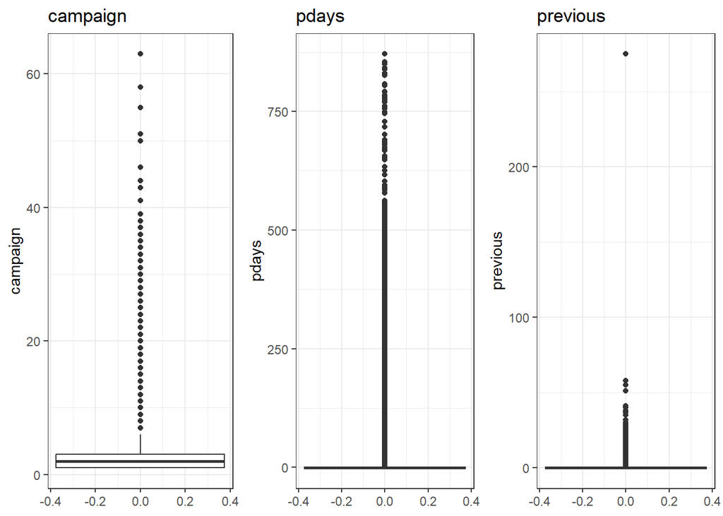

```r
grid.arrange(plot_list[[5]], plot_list[[6]], plot_list[[7]], ncol=3)
```

## Predictor variables: Categorical

- contact and poutcome columns have relatively large portion of “unknown” values.

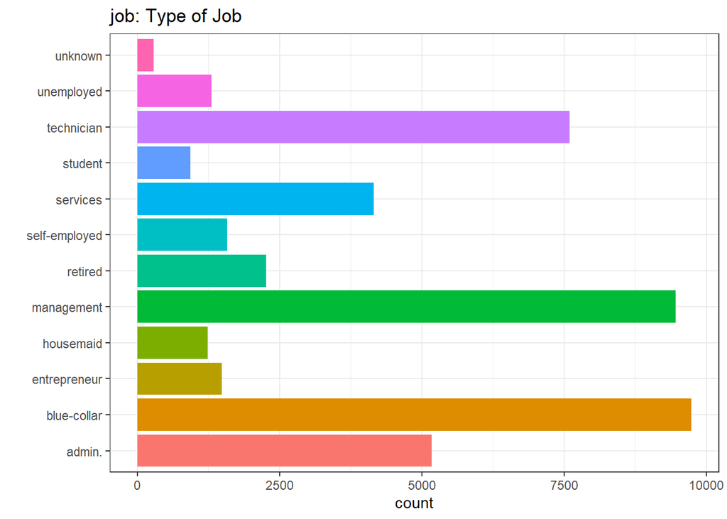

```r
desc <- c("Type of Job", "Marital status", "Education level", "Has credit in default?",
          "Has a housing loan?", "Has a personal loan?", "Contact communication type",
          "Last contact month of year", "Previous campaign results", "Term deposit subscribed?")
colnm2 <- colnames(bank[sapply(bank, is.factor)] %>% select(-y))

plot_list <- list()

for (i in 1:length(colnm2)) {
  plot_list[[i]] <- ggplot(data = bank) +
          geom_bar(aes(x = !!sym(colnm2[i]), fill=!!sym(colnm2[i])), show.legend = FALSE) +
          coord_flip() +
          ggtitle(paste0(colnm2[i],": ",desc[i])) + xlab("") + theme_bw()
}

plot_list[[1]]
```

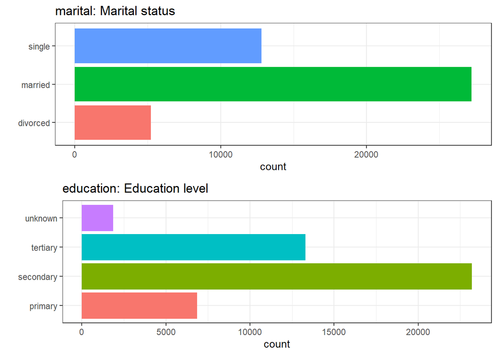

```r
grid.arrange(plot_list[[2]], plot_list[[3]], ncol=1)
```

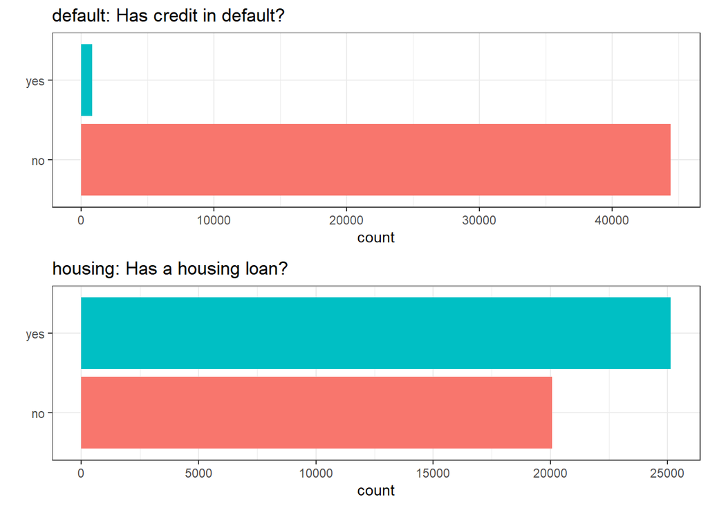

```r
grid.arrange(plot_list[[4]], plot_list[[5]], ncol=1)
```

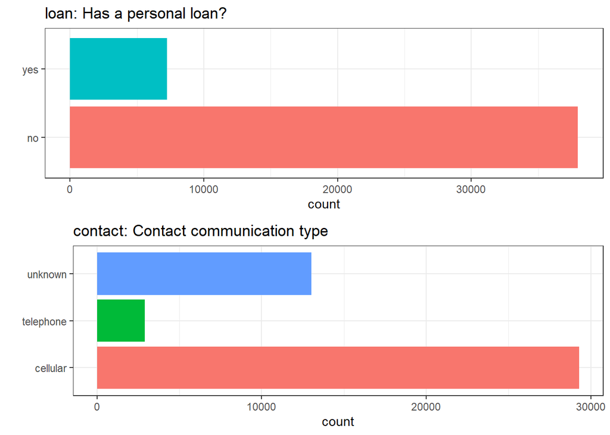

```r
grid.arrange(plot_list[[6]], plot_list[[7]], ncol=1)
```

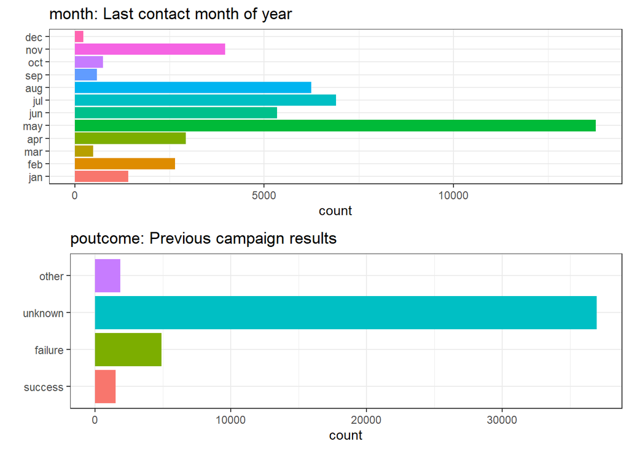

```r
grid.arrange(plot_list[[8]], plot_list[[9]], ncol=1)
```

## Relatioships

### Correlation

- pdays - poutcome(unknown) : -0.87
- pdays - poutcome(failure) : 0.70
- education(tertiary) - job(management) : 0.60
- poutcome(unknown) - previous : -0.53

```r
matrix.bank <- model.matrix(~., data=bank)
matrix.bank <- matrix.bank[,-1] ## remove intercept

data.frame(which(abs(cor(matrix.bank)) > 0.5 & cor(matrix.bank) != 1, arr.ind = TRUE)) %>%
  mutate(rowname=rownames(cor(matrix.bank))[row],
         colname=colnames(cor(matrix.bank))[col],
         corr = round(cor(matrix.bank)[cbind(row, col)],2)) %>%
  select(3:5) %>%
  arrange(desc(abs(corr)))
```

```
##                                rowname            colname  corr
## poutcomeunknown        poutcomeunknown              pdays -0.87
## pdays.1                          pdays    poutcomeunknown -0.87
## maritalsingle            maritalsingle     maritalmarried -0.77
## maritalmarried          maritalmarried      maritalsingle -0.77
## poutcomeunknown.2      poutcomeunknown    poutcomefailure -0.74
## poutcomefailure.1      poutcomefailure    poutcomeunknown -0.74
## poutcomefailure        poutcomefailure              pdays  0.70
## pdays                            pdays    poutcomefailure  0.70
## educationtertiary.1  educationtertiary educationsecondary -0.66
## educationsecondary  educationsecondary  educationtertiary -0.66
## educationtertiary    educationtertiary      jobmanagement  0.60
## jobmanagement            jobmanagement  educationtertiary  0.60
## poutcomeunknown.1      poutcomeunknown           previous -0.53
## previous                      previous    poutcomeunknown -0.53
```

*pdays - poutcome* + If the outcome of the last campaign was unknown, the bank re-contacts the customer as soon as possible. (correlation: -0.87) + If successful, the bank re-contacts the customer relatively quickly because this campaign is likely to be successful as well. + If the campaign was unsuccessful (failure or other), the bank reaches out to the customer at a longer interval because this campaign is likely to be unsuccessful as well. (correlation: 0.70)

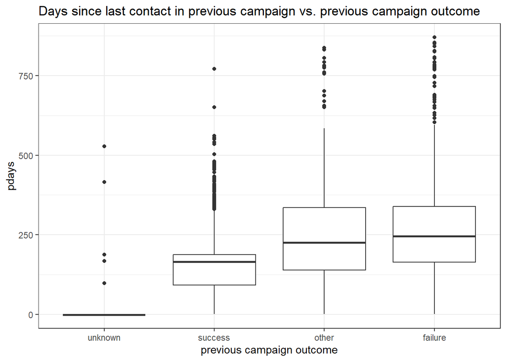

```r
ggplot(bank, aes(x=reorder(poutcome, pdays, FUN=median), y=pdays)) +
  geom_boxplot() +
  labs(title="Days since last contact in previous campaign vs. previous campaign outcome", x="previous campaign outcome") +
  theme_bw()
```

*education(tertiary) - job(management): 0.60*

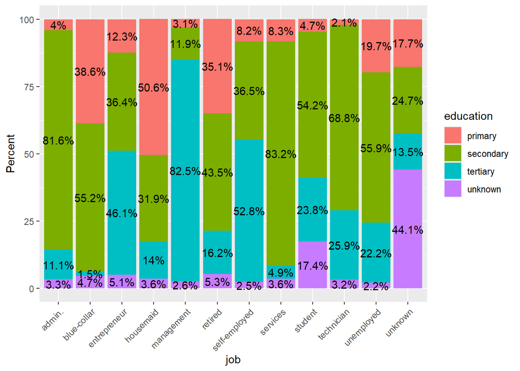

```r
bank %>% select(job, education) %>%
  group_by(job, education) %>% summarise(cnt=n(), .groups="drop") %>%
  group_by(job) %>% mutate(Percent = round(cnt/sum(cnt)*100,1)) %>%

  ggplot(aes(x=job, y=Percent, fill=education)) +
  geom_bar(stat="identity") +
  geom_text(aes(label=paste0(Percent,"%")), position = position_stack(vjust = 0.5)) +
  theme(axis.text.x = element_text(angle = 45, hjust = 1))
```

*poutcome(unknown) - previous: -0.53* Previous contacts for this client before this campaign vs. previous campaign outcome

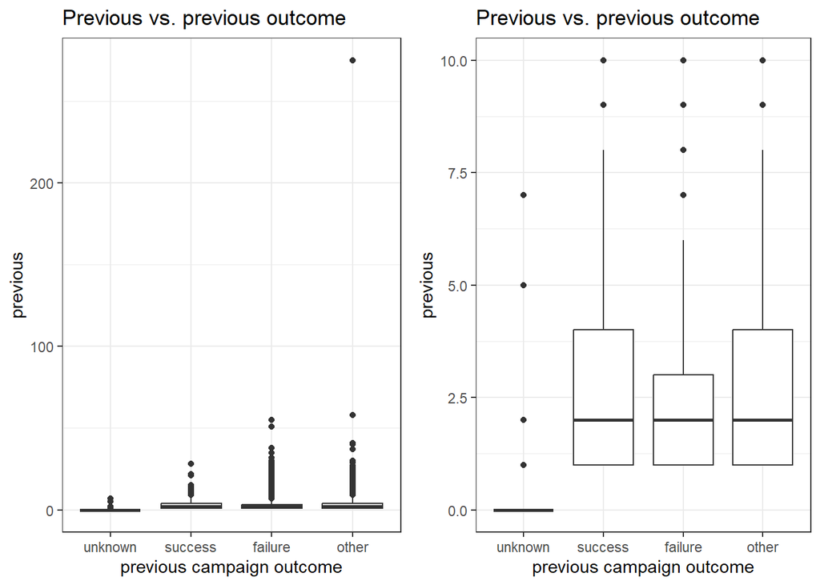

```r
gg1 <- ggplot(bank, aes(x=reorder(poutcome, previous, FUN=median), y=previous)) +
  geom_boxplot() +
  labs(title="Previous vs. previous outcome", x="previous campaign outcome") +
  theme_bw()

gg2 <- gg1 + coord_cartesian(ylim=c(0,10))

grid.arrange(gg1, gg2, ncol=2)
```

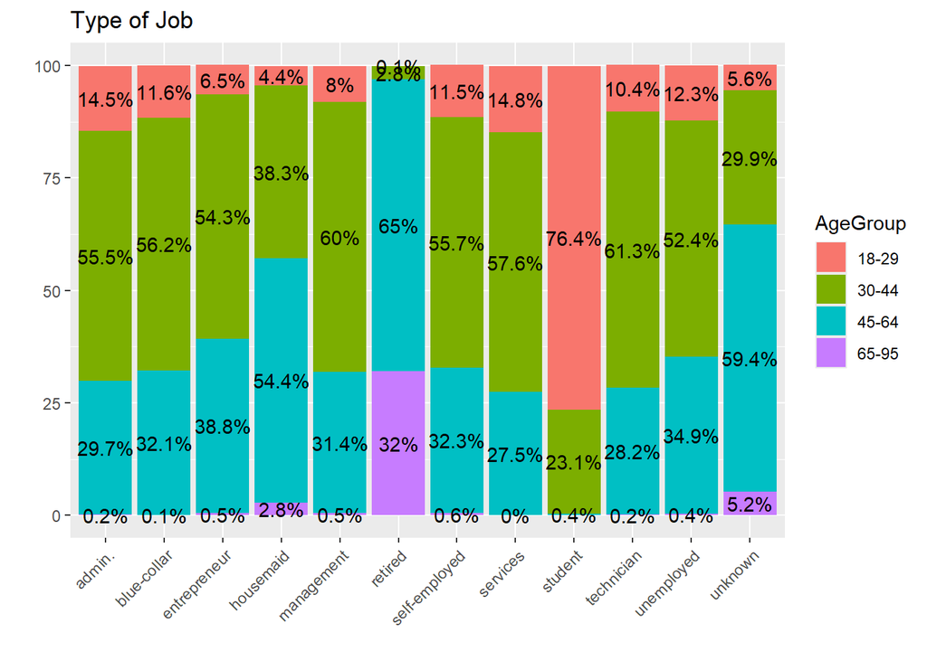

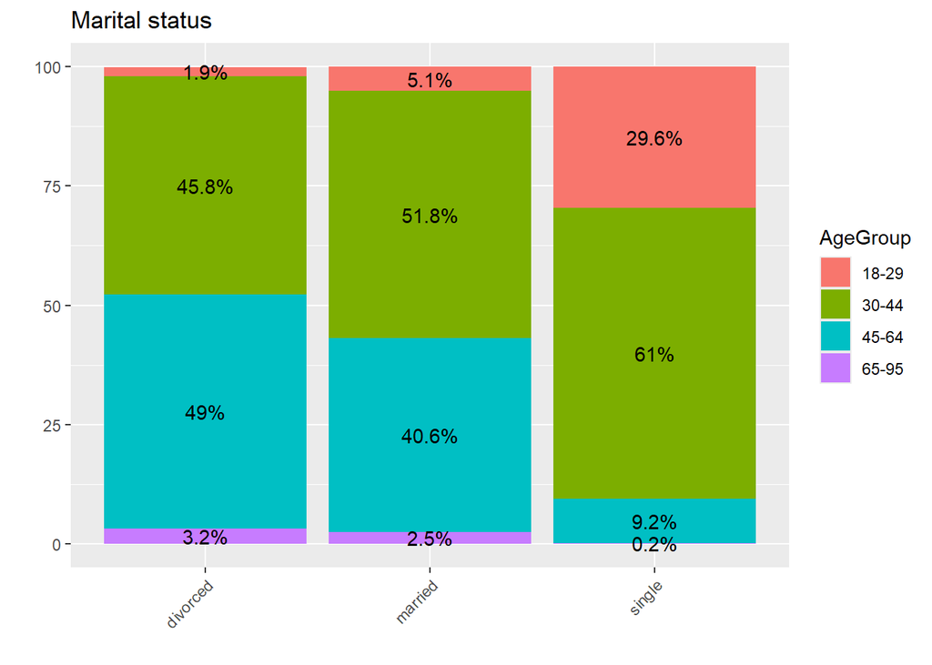

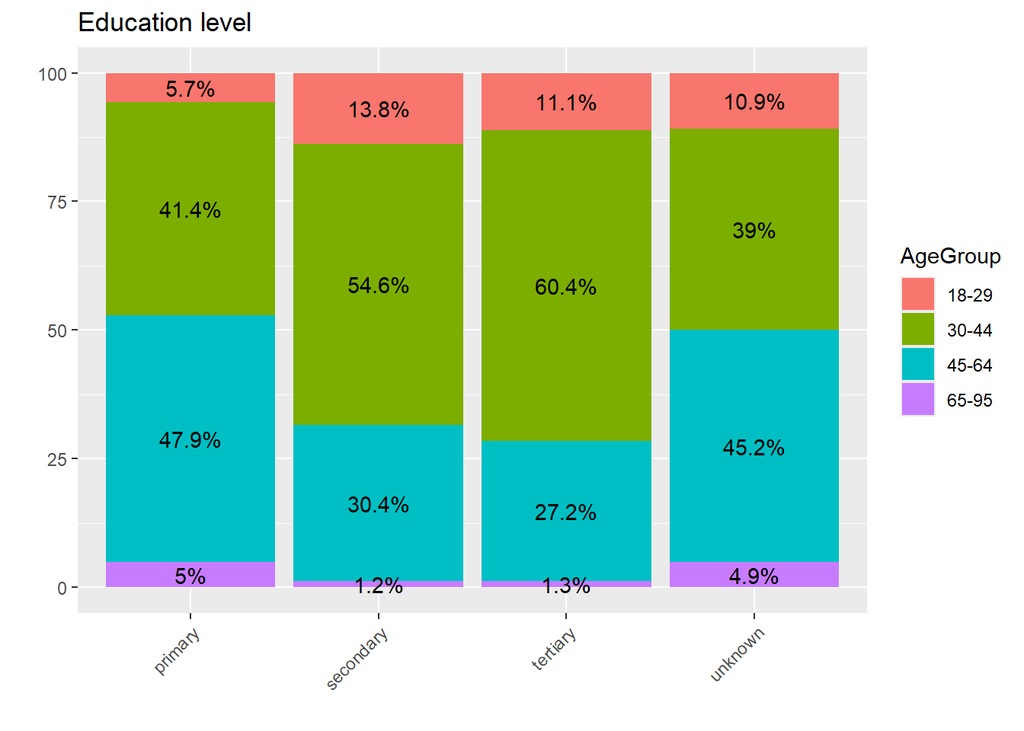

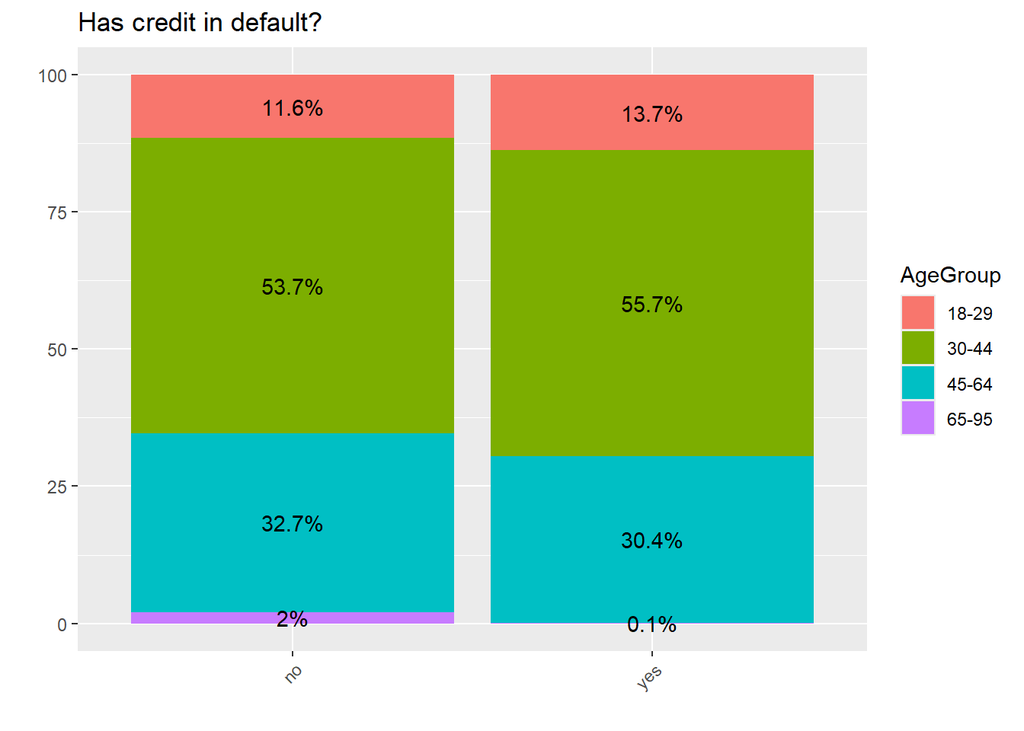

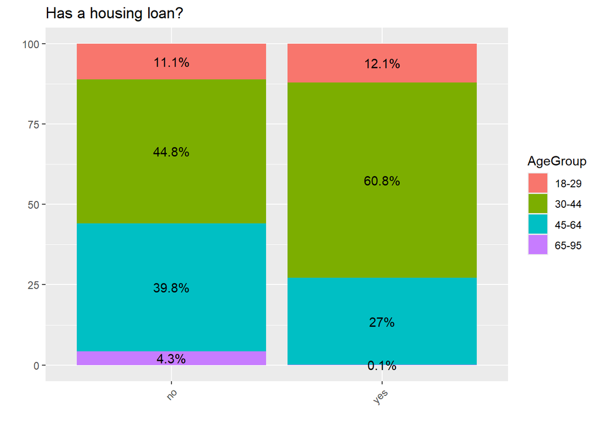

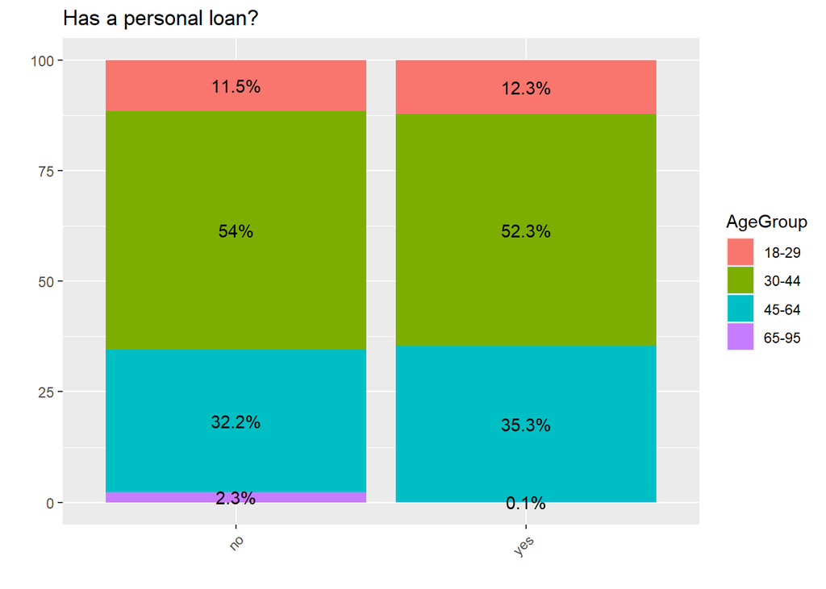

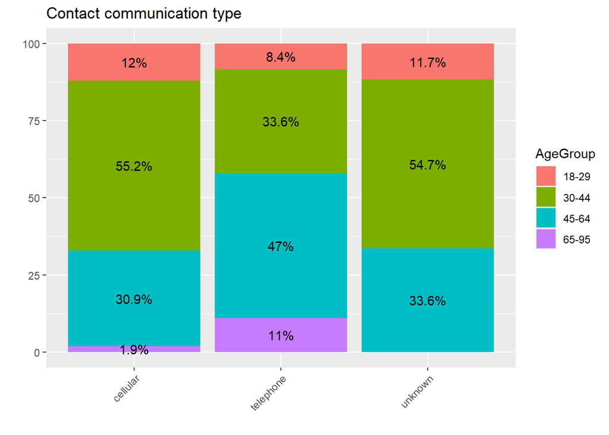

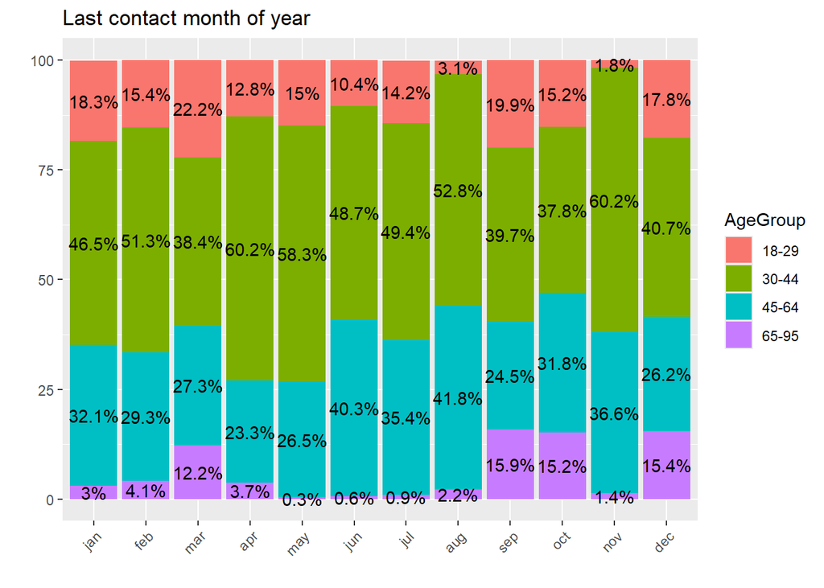

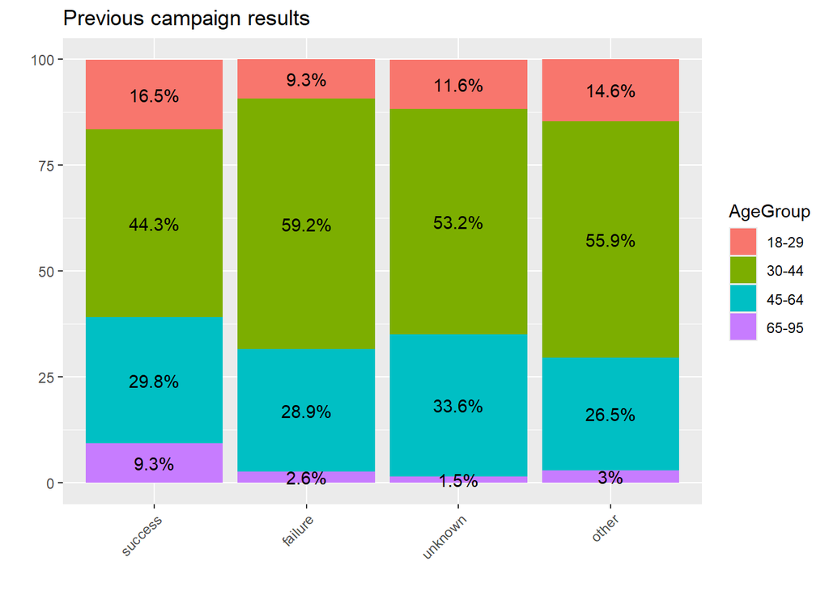

```r
# Early Adult: 18-29 years old
# Young Adult: 30-44 years old
# Middle-Aged Adult: 45-64 years old
# Elderly/Senior: 65 years old and older

desc <- c("Type of Job", "Marital status", "Education level", "Has credit in default?",
          "Has a housing loan?", "Has a personal loan?", "Contact communication type",
          "Last contact month of year", "Previous campaign results", "Term deposit subscribed?")

colnm <- colnames(bank[sapply(bank, is.factor)] %>% select(-y))

for (i in  1:length(colnm)) {
  print(bank %>%
      select(y,age,!!sym(colnm[i])) %>%
      mutate(AgeGroup=cut(bank$age, breaks = c(18, 30, 45, 64, 96),
                          labels = c("18-29", "30-44", "45-64", "65-95"),
                          right = FALSE)) %>%
      group_by(!!sym(colnm[i]), AgeGroup) %>%
      summarize(cnt=n(), .groups = "drop") %>%
      group_by(!!sym(colnm[i])) %>%
      mutate(Percent=round(cnt/sum(cnt)*100,1)) %>%
      ggplot(aes(x=!!sym(colnm[i]), y=Percent, fill=AgeGroup)) +
      geom_bar(stat="identity") +
      geom_text(aes(label=paste0(Percent,"%")), position = position_stack(vjust = 0.5)) +
      theme(axis.text.x = element_text(angle = 45, hjust = 1)) +
      labs(title=desc[i], x="", y=""))
}
```

#### Numerical variables vs. y

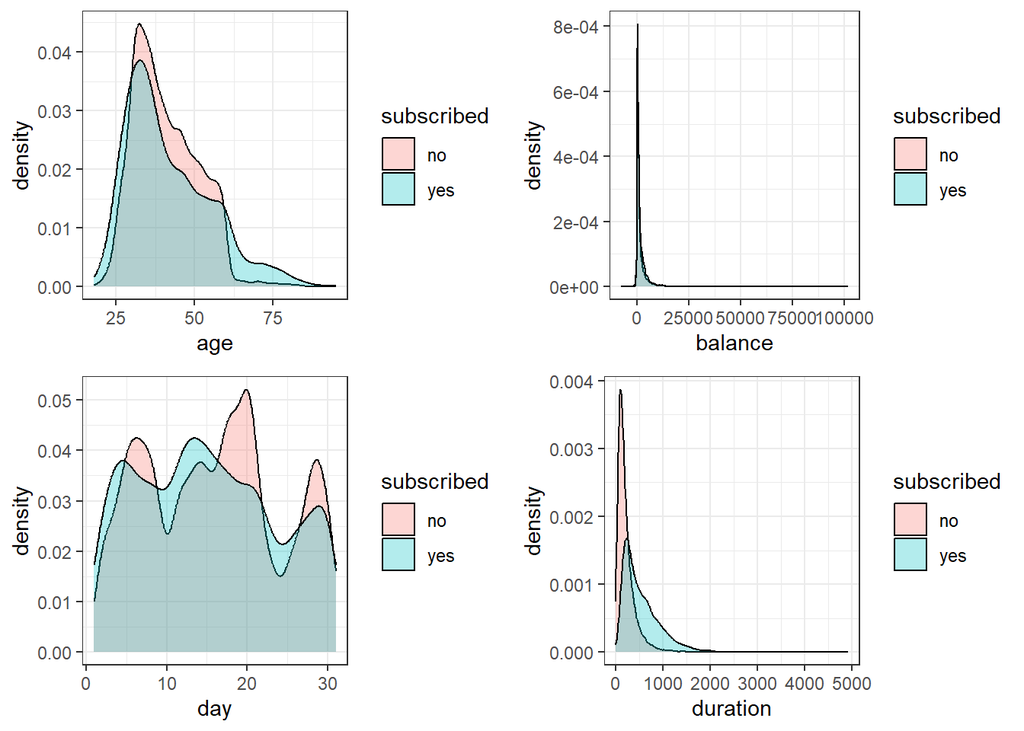

```r
gg1 <- ggplot(bank, aes(x=age, fill=y)) + geom_density(alpha=0.3) + labs(fill="subscribed") + theme_bw()
gg2 <- ggplot(bank, aes(x=balance, fill=y)) + geom_density(alpha=0.3) + labs(fill="subscribed") + theme_bw()
gg3 <- ggplot(bank, aes(x=day, fill=y)) + geom_density(alpha=0.3) + labs(fill="subscribed") + theme_bw()
gg4 <- ggplot(bank, aes(x=duration, fill=y)) + geom_density(alpha=0.3) + labs(fill="subscribed") + theme_bw()
gg5 <- ggplot(bank, aes(x=campaign, fill=y)) + geom_density(alpha=0.3) + labs(fill="subscribed") + theme_bw()
gg6 <- ggplot(bank, aes(x=pdays, fill=y)) + geom_density(alpha=0.3) + labs(fill="subscribed") + theme_bw()
gg7 <- ggplot(bank, aes(x=previous, fill=y)) + geom_density(alpha=0.3) + labs(fill="subscribed") + theme_bw()

grid.arrange(gg1, gg2, gg3, gg4, ncol=2)
```

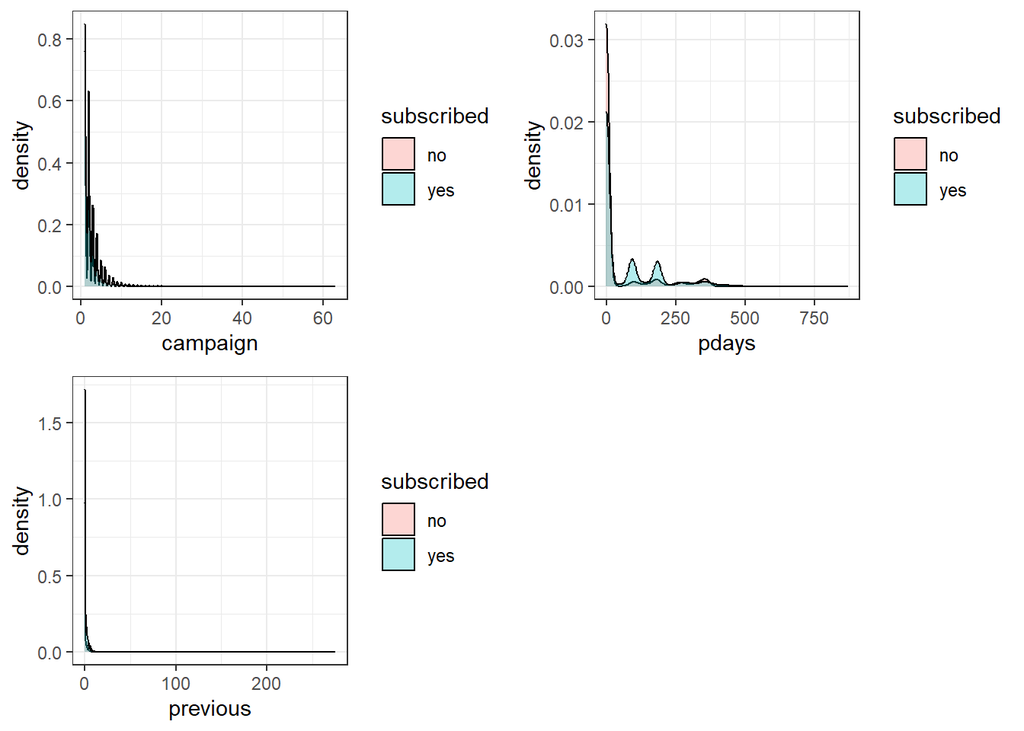

```r
grid.arrange(gg5, gg6, gg7, ncol=2)
```

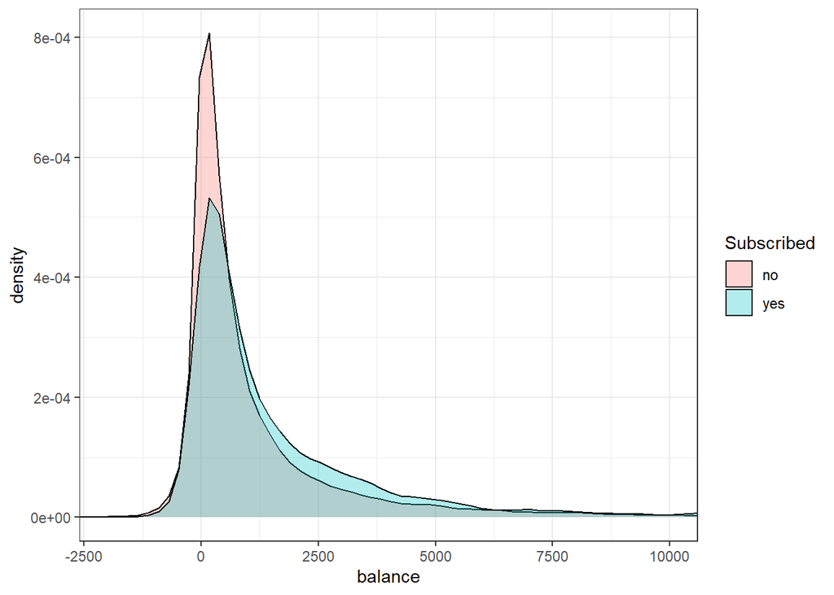

```r
ggplot(bank, aes(x=balance, fill=y)) + geom_density(alpha=0.3) + labs(fill="Subscribed") +
  coord_cartesian(xlim=c(-2000, 10000)) + theme_bw()
```

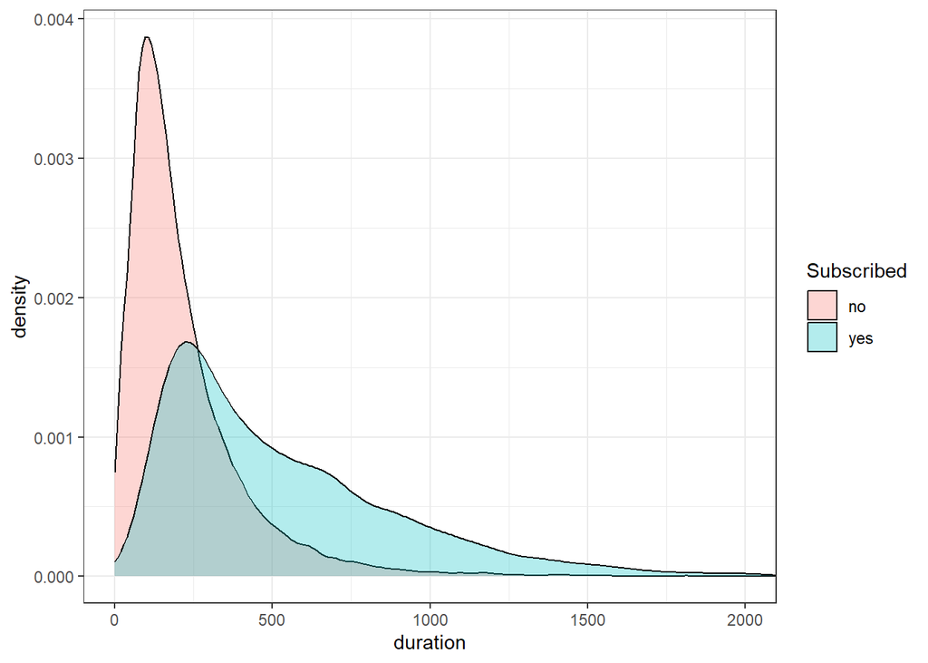

```r
ggplot(bank, aes(x=duration, fill=y)) + geom_density(alpha=0.3) + labs(fill="Subscribed") +
  coord_cartesian(xlim=c(0,2000)) + theme_bw()
```

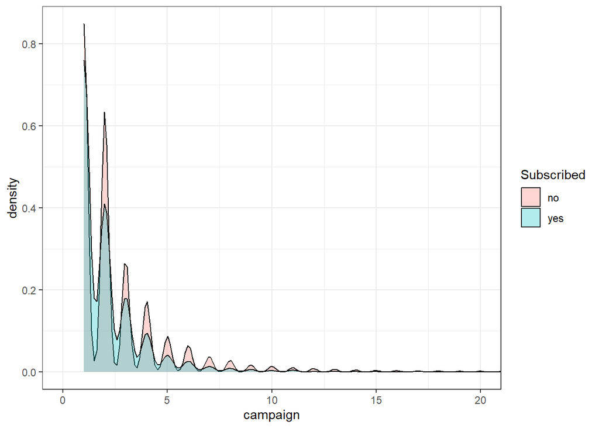

```r
ggplot(bank, aes(x=campaign, fill=y)) + geom_density(alpha=0.3) + labs(fill="Subscribed") +
  coord_cartesian(xlim=c(0,20)) + theme_bw()
```

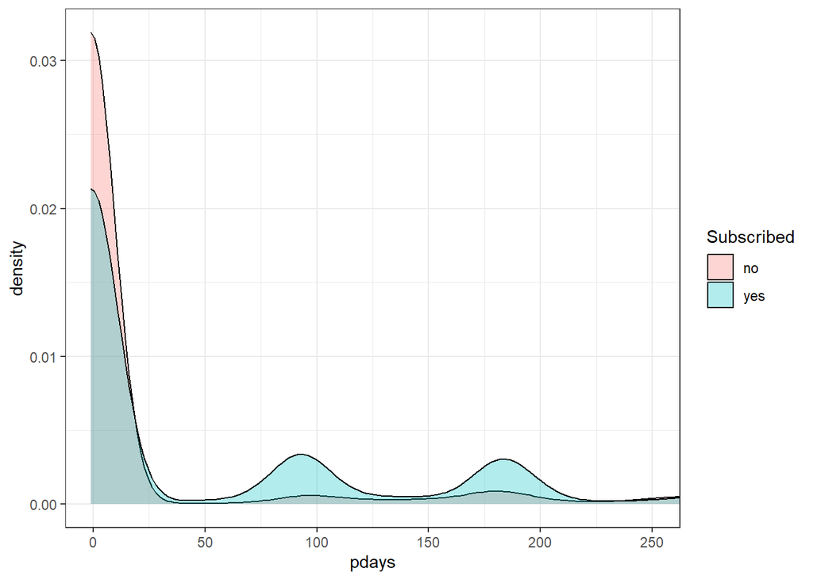

```r
ggplot(bank, aes(x=pdays, fill=y)) + geom_density(alpha=0.3) + labs(fill="Subscribed") +
  coord_cartesian(xlim=c(0,250)) + theme_bw()
```

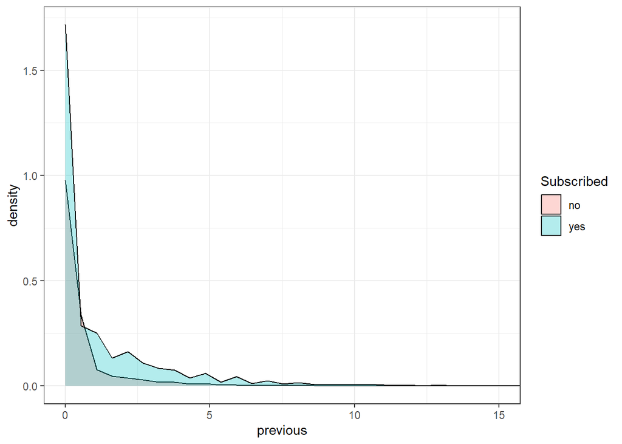

```r
ggplot(bank, aes(x=previous, fill=y)) + geom_density(alpha=0.3) + labs(fill="Subscribed") +
  coord_cartesian(xlim=c(0,15)) + theme_bw()
```

*pdays: Number of days that passed by after the client was last contacted from a previous campaign (numeric, -1 means client was not previously contacted)*

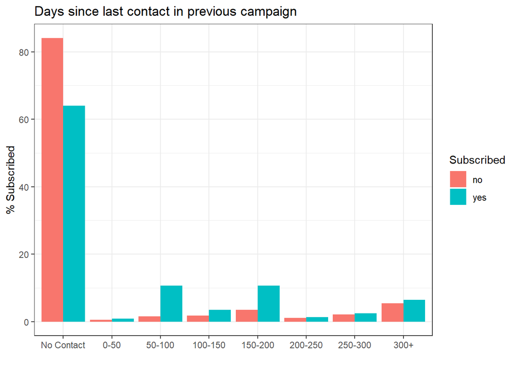

```r
bank %>%
  select(y,pdays) %>%
  mutate(pday=cut(bank$pdays, breaks = c(-1, 0, 50, 100, 150, 200, 250, 300, Inf),
                      labels = c("No Contact", "0-50", "50-100", "100-150", "150-200", "200-250", "250-300", "300+"),
                      right = FALSE)) %>%
  group_by(y, pday) %>%
  summarise(cnt=n(), .groups = "drop") %>%
  group_by(y) %>%
  mutate(Percent=round(cnt/sum(cnt)*100,1)) %>%
  ggplot(aes(x=pday, y=Percent, fill=y)) +
  geom_bar(stat="identity", position="dodge") +
  labs(title="Days since last contact in previous campaign", x="", y="% Subscribed", fill="Subscribed") +

  theme_bw()
```

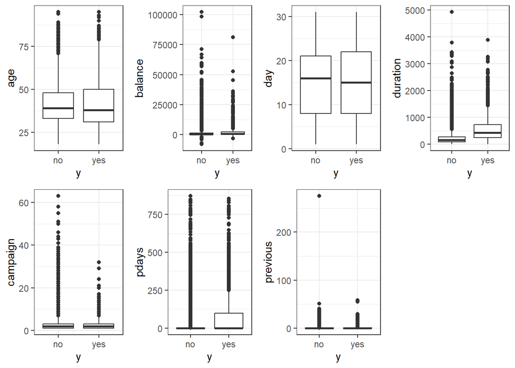

```r
gg1 <- bank %>% ggplot(aes(x=y, y=age)) + geom_boxplot() + theme_bw()
gg2 <- bank %>% ggplot(aes(x=y, y=balance)) + geom_boxplot() + theme_bw()
gg3 <- bank %>% ggplot(aes(x=y, y=day)) + geom_boxplot() + theme_bw()
gg4 <- bank %>% ggplot(aes(x=y, y=duration)) + geom_boxplot() + theme_bw()
gg5 <- bank %>% ggplot(aes(x=y, y=campaign)) + geom_boxplot() + theme_bw()
gg6 <- bank %>% ggplot(aes(x=y, y=pdays)) + geom_boxplot() + theme_bw()
gg7 <- bank %>% ggplot(aes(x=y, y=previous)) + geom_boxplot() + theme_bw()

grid.arrange(gg1, gg2, gg3, gg4, gg5, gg6, gg7, ncol=4)
```